# Choice of VIPCAL Model

Hisham M Shaikh

2022-12-21

**1.0 Setting Up the environment**  
**1.1 Setting working directory**  
`setwd("C:/Users/hisham.shaikh/OneDrive - UGent/Projects/FCM_R/ViralProduction_R"`  
**1.2 Installing Libraries**

```r
library("lme4")
library("emmeans")
```

**2.0 Importing and wrangling data**

```r
source("C:/Users/hisham.shaikh/OneDrive - UGent/Projects/FCM_R/ViralProduction_R/vp_functions.R", echo=TRUE) #functions written to ease manipulation
NJ1<- read.csv("NJ1.csv")
lmer_data<- df_sr(NJ1)

#only calculating for total virus for now.

lmer_data<- lmer_data[lmer_data$count =="c_Viruses",]

lmer_data$Sample_Type <- as.factor(lmer_data$Sample_Type)
lmer_data$Timepoint2<- as.factor(lmer_data$Timepoint)

lmer_data[lmer_data$Sample_Type == "VPC",]$Replicate<- replace(lmer_data[lmer_data$Sample_Type == "VPC",]$Replicate, lmer_data[lmer_data$Sample_Type == "VPC",]$Replicate == c("1","2", "3"), c("4", "5", "6"))

lmer_data[order(lmer_data$Replicate),]
```

**3.0 Modeling**  
Adding all possible models

```r
#Linear Models

m1<- lm(data = lmer_data, formula = value~ Sample_Type + Timepoint2 + Replicate)
summary(m1)  #all three predictors
m2<- lm(data = lmer_data, formula = value~ Sample_Type + Timepoint2)
summary(m2) #without replicate
m3<- lm(data = lmer_data, formula = value~ Sample_Type + Timepoint2 + Replicate + Sample_Type*Timepoint2)
summary(m3) #with an interaction between sample type and time points
m4<- lm(data = lmer_data, formula = value~ Sample_Type + Timepoint2 +  Sample_Type*Timepoint2)
summary(m4) #with an interaction between sample type and time points and without replicates

#Linear Mixed Effect models
#As we wanted to keep the identity of replicates. We add replicates as the random effect factor

m5<- lmer(data = lmer_data, formula = value~ Sample_Type + Timepoint2 + Sample_Type*Timepoint2 + (1 | Replicate))
summary(m5) #Both predictors and interaction between them
m6<- lmer(data = lmer_data, formula = value~  Sample_Type*Timepoint2 + (1 | Replicate))
summary(m6) #Only interaction term. We are trying to predict value over a combination of sample type and time points when we keep all points of a replicate together.
m7<- lmer(data = lmer_data, formula = value~  Sample_Type*Timepoint2 + (1 + value| Replicate))
```

```
## boundary (singular) fit: see help('isSingular')
```

```r
summary(m7) #only interaction term, but where replicates vary with value. This model doesn't make sense as what we're basically saying is: we are trying to predict value over a combination of sample type and time points when replicates vary with value itself. This collapses our model.
m8<- lmer(data = lmer_data, formula = value~  Sample_Type*Timepoint2 + (1 + Sample_Type| Replicate))
summary(m8) #only interaction term, but where replicates vary with sample type. We are trying to predict value over a combination of sample type and time points when replicates vary with sample_type.
```

AIC was calculated for each of these models

```r
AIC.table <- MuMIn::model.sel(m1, m2, m3, m4, m5, m6, m7, m8)
AIC.table <- AIC.table[, c("df", "logLik", "AICc", "delta")]
AIC.table
```

```
##    df     logLik      AICc    delta
## m7 16  -84.95748  230.5465   0.0000
## m5 14 -362.10354  772.2071 541.6605
## m6 14 -362.10354  772.2071 541.6605
## m8 16 -361.78743  784.2064 553.6599
## m4 13 -526.61560 1095.7767 865.2301
## m3 17 -520.67833 1109.3567 878.8101
## m2  8 -551.35174 1124.0368 893.4903
## m1 12 -550.02427 1137.6138 907.0672
```

As you can see the best models are m7, m5, m6, and m8 (m7> m5, m6 > m8). All of them are mixed effect models. m5 and m6 are identical in terms of their assessment. Therefore, there is no effect of adding Sample Type and Timepoint as separate predictor variables.  
m7 is bogus, as we previously established

Yet, let’s assess the fit of these models.

*Normalized Residuals*

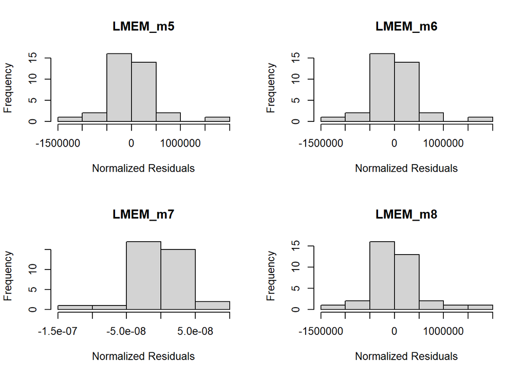

```r
par(mfrow = c(2,2))
for( model in 5:8){
 a<- paste0("m", model)

hist(resid(get(a)),
      xlab = "Normalized Residuals",
     main = paste("LMEM", a , sep = "_"))

}
```

*Normalized Residuals vs Predicted Values plots*

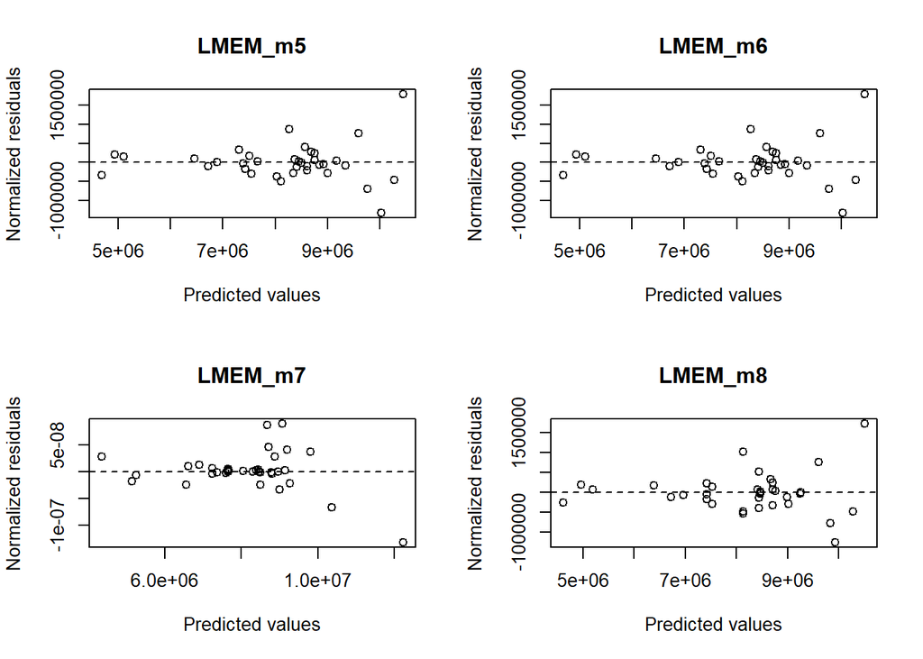

```r
par(mfrow = c(2,2))
for( model in 5:8){
  a<- paste0("m", model)
   plot(resid(get(a)) ~ fitted(get(a)),
        xlab = "Predicted values",
        ylab = "Normalized residuals",
        main = paste("LMEM", a , sep = "_"))
   abline(h = 0, lty = 2)

}
```

Let’s plot the predicted vs observed values to asess the models further

*Normalized Residuals vs Replicates plots*

```
## [1] "m5"
```

```
## [1] "m6"
```

```
## [1] "m7"
```

```
## [1] "m8"
```

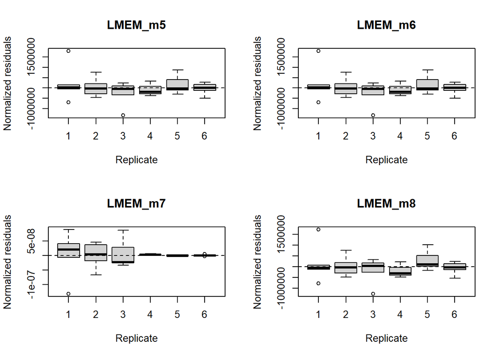

```r
par(mfrow = c(2,2))
for( model in 5:8){
  a<- paste0("m", model)
  print(a)
  boxplot(resid(get(a)) ~ Replicate,
          data = lmer_data,
          xlab = "Replicate",
          ylab = "Normalized residuals",
          main = paste("LMEM", a , sep = "_"))

  abline(h = 0, lty = 2)

}
```

*Predicted Values*

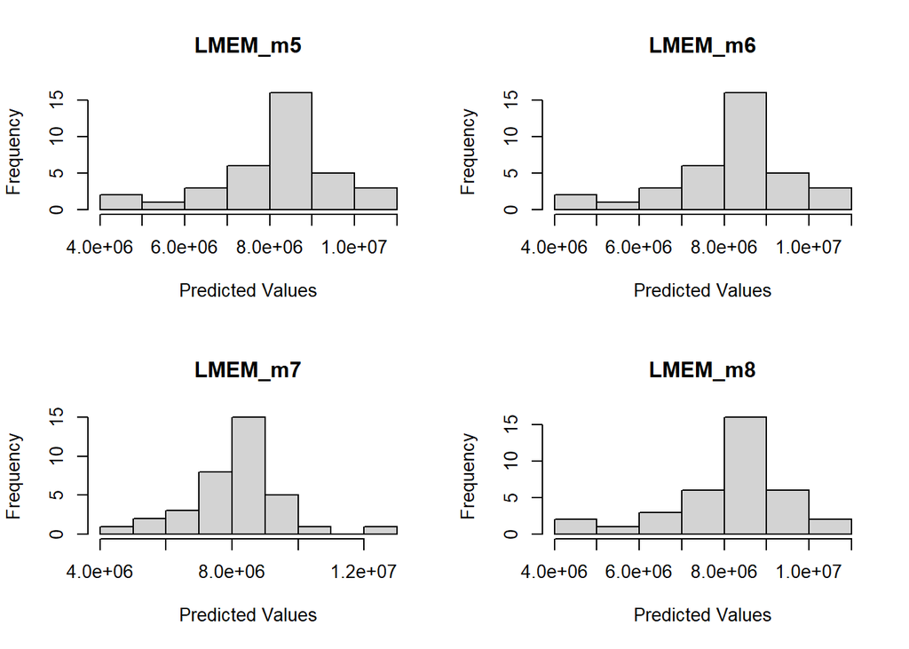

```r
par(mfrow = c(2,2))
for( model in 5:8){
 a<- paste0("m", model)

hist(predict(get(a)),
      xlab = "Predicted Values",
     main = paste("LMEM", a , sep = "_"))

}
```

*Predicted vs Observed Values plots*

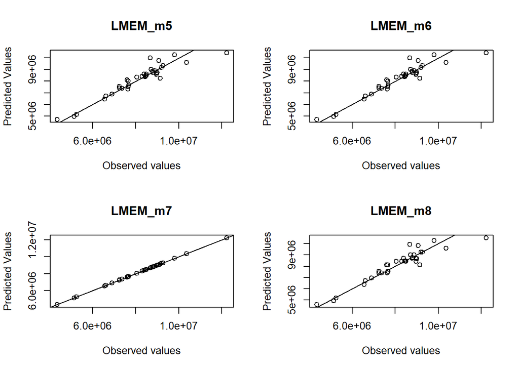

```r
par(mfrow = c(2,2))
for( model in 5:8){
  a<- paste0("m", model)
  plot(predict(get(a)) ~ lmer_data$value,
       xlab = "Observed values",
       ylab = "Predicted Values",
       main = paste("LMEM", a , sep = "_"))
  abline(a= 0, b = 1)

}
```

*Our winner is M6!*